# Project 2

Brian Weinfeld

June 26, 2018

## Overview

I have been tasked with developing a logistic regression that will accurately determine whether a neighborhood in a major city has a crime rate either above or below the median rate. The data set I have been provided with has 466 observations across 13 predictors.

I will begin by exploring the data set as a whole and then each individual predictors.

## Data Exploration

```r
raw.data %>%
  map_dbl(~sum(is.na(.))/nrow(raw.data))
```

```
##      zn   indus    chas     nox      rm     age     dis     rad     tax
##       0       0       0       0       0       0       0       0       0
## ptratio   black   lstat    medv  target
##       0       0       0       0       0
```

Initial inspection of the data very helpfully shows that there are no missing values. Thus, we will not need to impute any data or remove/modify any of the predictors before individual analysis.

```r
set.seed(123)
part <- caret::createDataPartition(raw.data$target, p=0.8, list=FALSE)
training <- raw.data %>%
  filter(row_number() %in% part)
testing <- raw.data %>%
  filter(!row_number() %in% part)
```

I partition the data into a training set and testing set. The training set contains 80% of the total number of observations. Using caret’s createDataPartition method ensures that each partition has target values roughly representation of the overall population. With this data set, there is an appoximate even split between below the median crime rate (0) and above (1).

```r
Predictor.Disp <- function(x){
  require(gridExtra)
  plot.1 <- ggplot(training, aes_string(x)) +
    geom_density()

  plot.2 <-
    training %>%
      mutate(target = factor(target)) %>%
      ggplot(aes_string('target', x)) +
      geom_boxplot() +
      geom_point(alpha=0.2)

  grid.arrange(plot.1, plot.2, ncol=2)
}
```

I created a function called Predictor.Disp that is designed to help me in displaying each predictor. It produces a density plot of the predictor in order to aid in determining the predictors distribution and a box plot faceted by the target response variable in order to aid in comparison of the spread between the two groups.

### zn

zn: proportion of residential land zoned for large lots (over 25000 square feet)

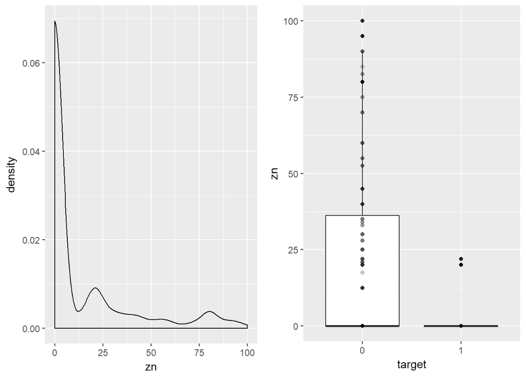

```r
Predictor.Disp('zn')
```

### indus

indus: Proportion of non-retail business acres per suburb

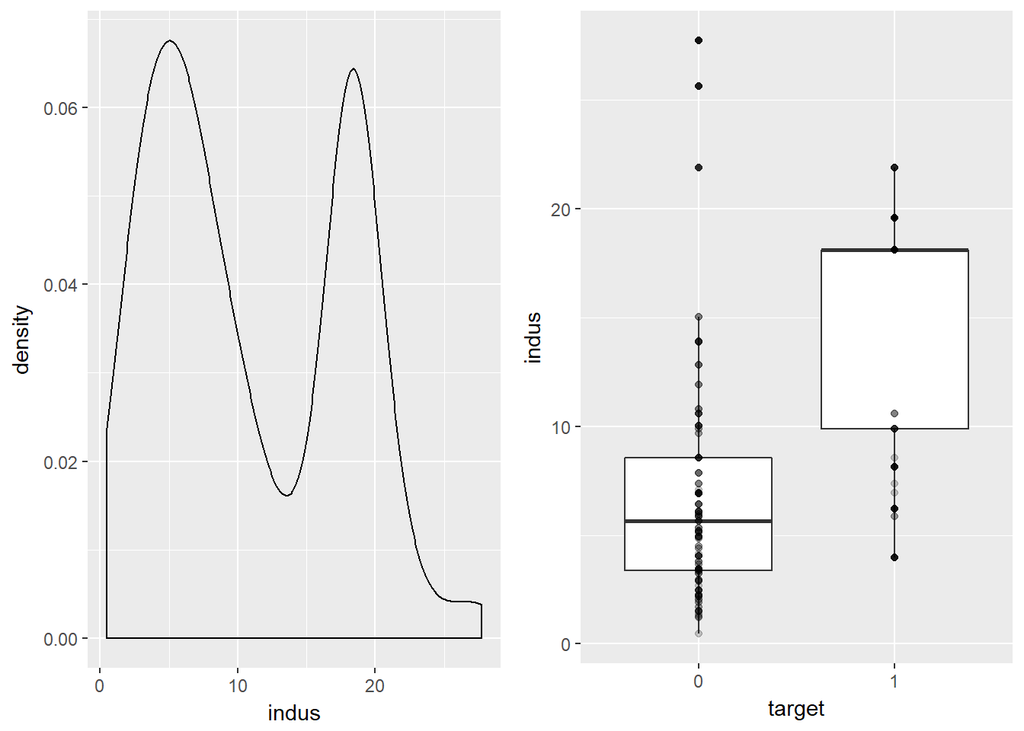

```r
Predictor.Disp('indus')
```

The density plot is bimodal indicating that indus is typically either ‘low’ or ‘high’. The spread of the predictor in the box plot is showing that higher indus is associated with higher crime.

### chas

chas: A dummy variable for whether the suburb borders the Charles River

This is the only categorical variable in the predictor set. As per our textbook, ‘when x is a dummy variable, it can be shown that the log odds are also a linear function of x’.

### nox

nox: Nitrogren oxides concentration (parts per 10 million)

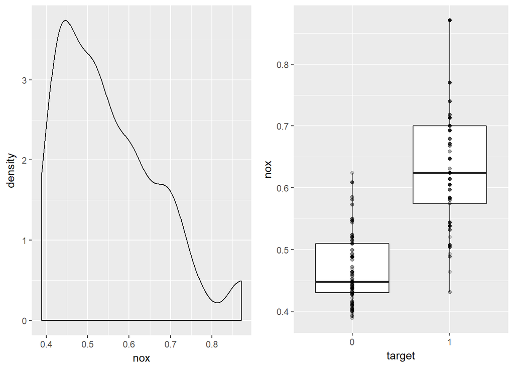

```r
Predictor.Disp('nox')
```

The nox variable has a slightly skew distribution and the fairly even spread in the boxplot. As per the textbook, ‘when doncuting a binary regression with a skewed predictor, it is often easiest to assess the need for x and log(x) by including them both in the model.’

### rm

rm: Average number of rooms per dwelling

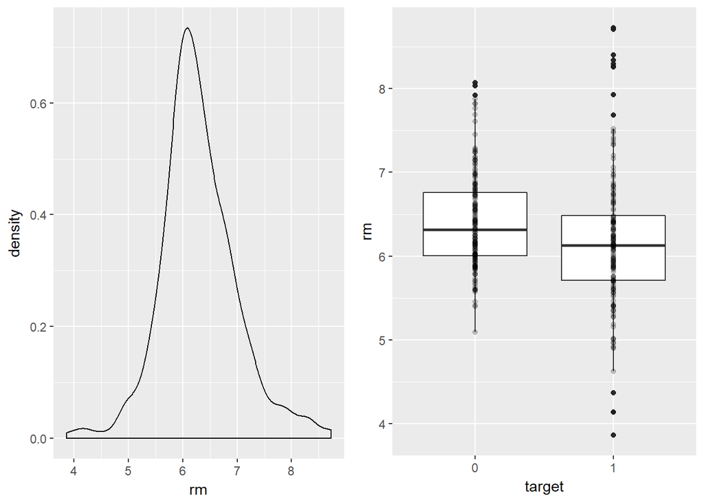

```r
Predictor.Disp('rm')
```

The rm predictor is very nicely normally distributed with a nearly equal median value when seperated by target. Despite the ease of working with normally distributed data, the fact that the spread and median in the boxplot is so similar suggested that rm may not produce a statistically significant difference.

### age

age: Proportion of owner-occupied units built prior to 1940

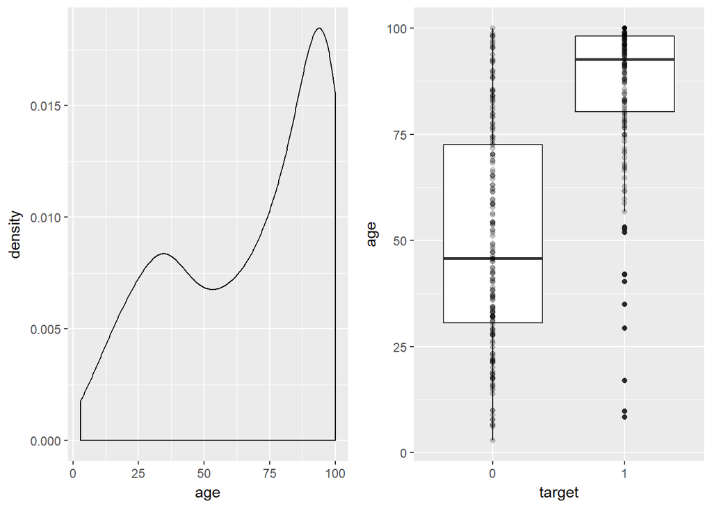

```r
Predictor.Disp('age')
```

The age predictor is heavily skewed indicating that a tranformation may be necessary. As with the ‘nox’ predictor, it may be required to add a log term to the model.

### dis

dis: Weighted mean of distances to five Boston employment centers

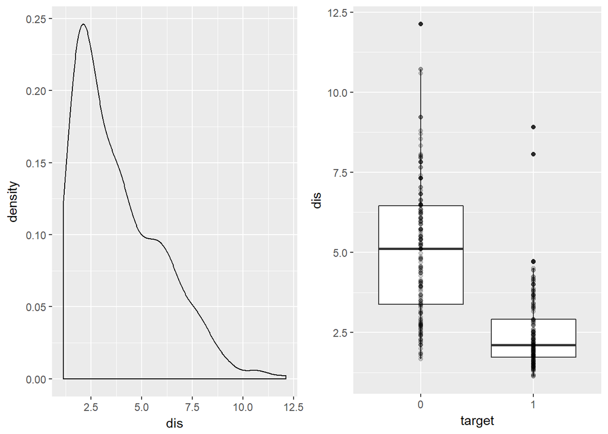

```r
Predictor.Disp('dis')
```

dis is similar to the above skewed predictors. There appears to be a demonstrable difference when considering higher crime locations and lower crime locations.

### rad

rad: index of accessibility to radial highways

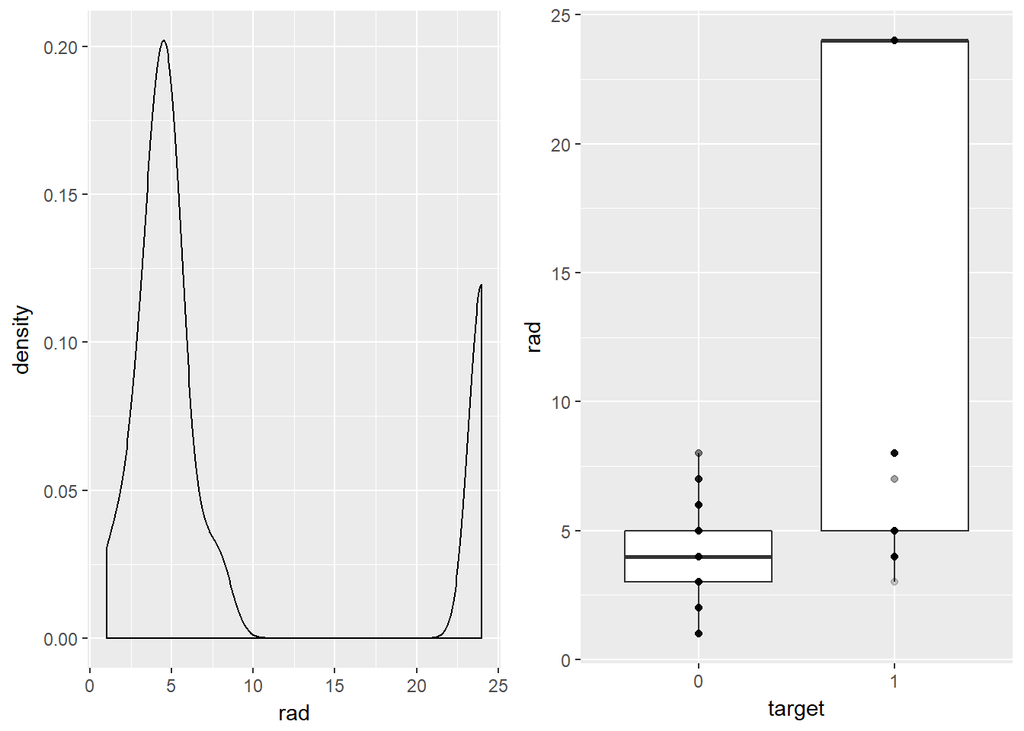

```r
Predictor.Disp('rad')
```

The ‘rad’ variable, like ‘zn’ and ‘indus’ above, is strongly bimodal, perhaps even moreso than those variables. This again indicates that ‘rad’ can be identified as either ‘high’ or ‘low’.

### tax

tax: Full-value property-tax rate per $10,000

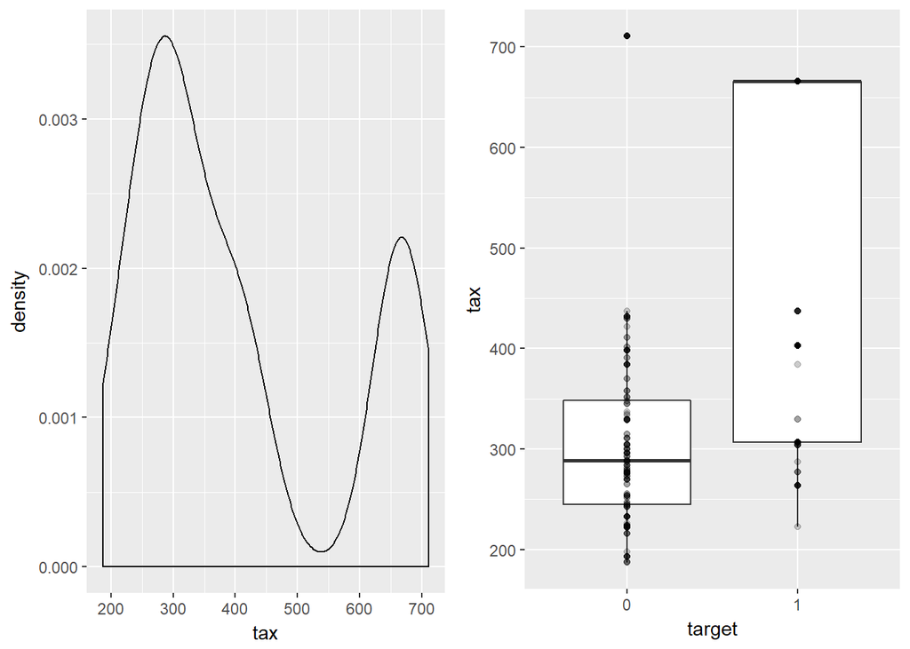

```r
Predictor.Disp('tax')
```

‘tax’, like ‘rad’ is also highly bimodal. This indicates a large number of low tax areas and a small number of high tax areas. Interestingly, it is the high tax areas that seem to exhibit more crime.

### ptratio

ptratio: pupil-teacher ratio by town

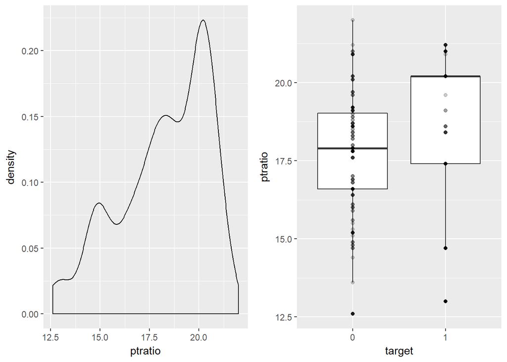

```r
Predictor.Disp('ptratio')
```

‘ptratio’ is skewed and may be in need of transforming.

### black

black:
$$1000(B_{k}-0.63)^2$$
where
$$B_{k}$$
is the proportion of blacks by town

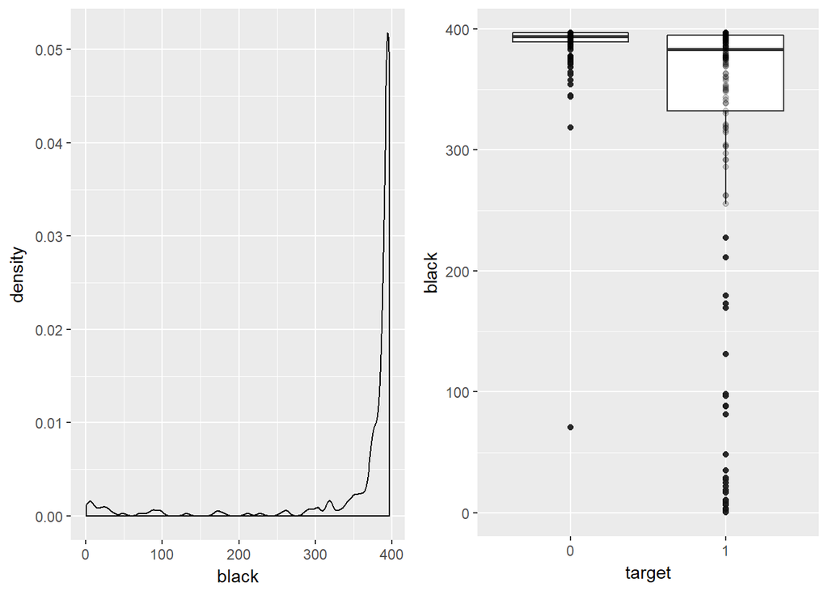

```r
Predictor.Disp('black')
```

‘black’ is more simiarl to the first predictor ‘zn’ in that nearly all the data is centered around a very small range with a number of outliers.

### lstat

lstat: lower status of the population (percent)

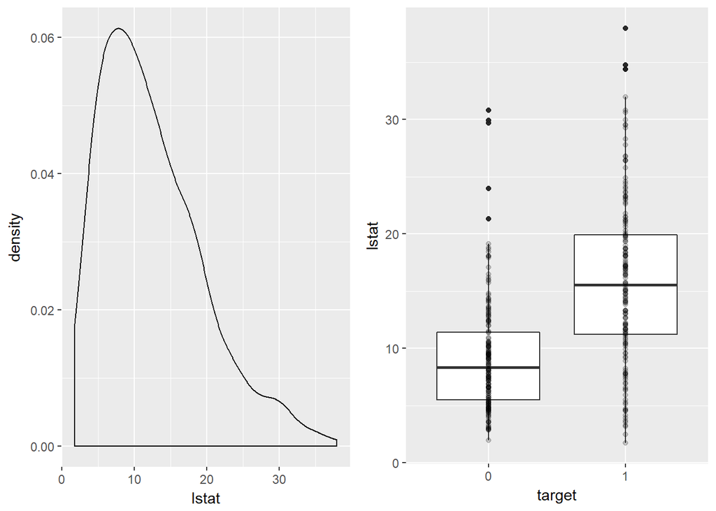

```r
Predictor.Disp('lstat')
```

‘lstat’ is fairly normally, similar to ‘rm’ however the boxplots indicate that the difference between low and high crime areas may be significant.

### medv

medv: Median value of owner-occupied homes in $1000s

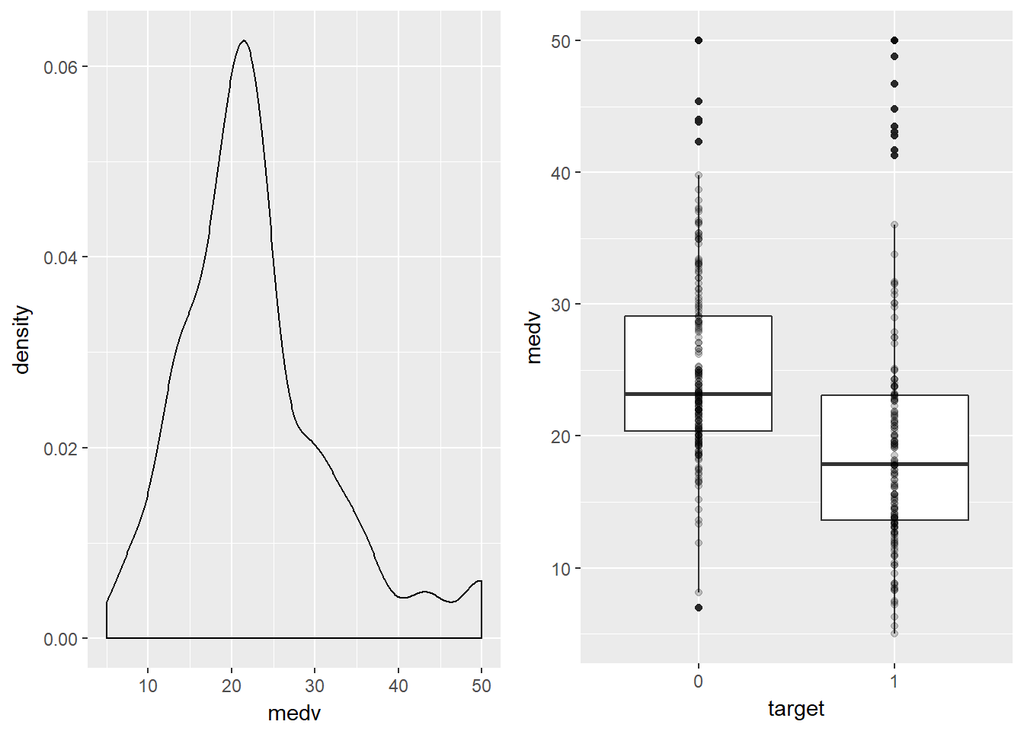

```r
Predictor.Disp('medv')
```

The final predictor is nearly normal and the boxpots have a roughly equal variance.

### Conclusion

In conclusion the 13 predictors can be grouped roughly as followed:

- Nearly Normal: rm, lstat, medv
- Bimodal / Highly Segregated: zn, indus, rad, tax, black
- Skewed: nox, age, dis, ptratio
- Categorical: chas

## Data Preperation

I will begin by altering the Bimodal / Highly Segregated predictors. I found a number of articles online indicating that this should NOT done or at least done with consideration. By bucketing continuous variables I will lose some of the predictive power that might be present in the variable. These concerns can be eased somewhat due to the fact that the data is highly segregated (the question is almost in essance asking for a ‘high’ or ‘low’ response) and that there are several other continuous predictors.

```r
training.cat <- training %>%
  mutate(chas.cat = factor(chas),
         zn.cat = factor(ifelse(zn == 0, 0, 1)),
         indus.cat = factor(ifelse(indus < 14, 0, 1)),
         rad.cat = factor(ifelse(rad <= 15, 0, 1)),
         tax.cat = factor(ifelse(tax <= 540, 0, 1)),
         black.cat = factor(ifelse(black <= 390, 0, 1))) %>%
  select(-chas, -zn, -indus, -rad, -tax, -black)
```

There are several other transformations that must be done but first I would like to build a model with the data I have collected thus far.

## Model 1

For this model I will only using the 6 categorical predictors. As per the textbook I know that each predictor will be linearly related to the log odds and thus the model will be valid. In addition, I may be able to glean additional helpful information from the model.

```r
model.1 <- glm(target ~ chas.cat + zn.cat + indus.cat + rad.cat + tax.cat + black.cat, data=training.cat,
               family=binomial)
summary(model.1)
```

```
##
## Call:
## glm(formula = target ~ chas.cat + zn.cat + indus.cat + rad.cat +
##     tax.cat + black.cat, family = binomial, data = training.cat)
##
## Deviance Residuals:
##      Min        1Q    Median        3Q       Max
## -2.11322  -0.69019  -0.40967   0.00011   2.24483
##
## Coefficients:
##              Estimate Std. Error z value Pr(>|z|)
## (Intercept)   -0.3173     0.2707  -1.172  0.24105
## chas.cat1      0.8937     0.5708   1.566  0.11744
## zn.cat1       -1.1224     0.3499  -3.208  0.00134 **
## indus.cat1     2.4368     0.4696   5.189 2.11e-07 ***
## rad.cat1      39.0288  4834.8353   0.008  0.99356
## tax.cat1     -21.1679  4708.9460  -0.004  0.99641
## black.cat1    -0.9959     0.3157  -3.155  0.00161 **
## ---
## Signif. codes:  0 '***' 0.001 '**' 0.01 '*' 0.05 '.' 0.1 ' ' 1
##
## (Dispersion parameter for binomial family taken to be 1)
##
##     Null deviance: 516.12  on 372  degrees of freedom
## Residual deviance: 259.50  on 366  degrees of freedom
## AIC: 273.5
##
## Number of Fisher Scoring iterations: 18
```

Looking at the summary there are two predictors, ‘rad.cat’ and ‘tax.cat’, that appear to be completely worthless with p-value of essentially 1. However, upon further inspection, it turns out there is a reasonable explanation for this result.

```r
car::vif(model.1)
```

```
##  chas.cat    zn.cat indus.cat   rad.cat   tax.cat black.cat
##  1.010948  1.013531  1.014106 19.456012 19.456013  1.010308
```

The ‘rad.cat’ and ‘tax.cat’ have wide std. error due to high multi-collinearity. In fact, it turns out that these predictors are nearly identical sharing over 98% of the same values!

```r
nrow(training.cat %>% filter(rad.cat == tax.cat)) / nrow(training.cat)
```

```
## [1] 0.9865952
```

Apparently being close to a radial highway essentially means that you pay higher taxes and vice versa. It is clear that we do not need both of this variables. I am removing ‘rad.cat’ as ‘tax.cat’ ends up being statistically significant in the remaining models. I need to be cognizant of the fact that this may be overfitting the training data and explore alternate possibilities later on.

```r
model.1.2 <- glm(target ~ chas.cat + zn.cat + indus.cat + tax.cat + black.cat, data=training.cat,
               family=binomial)
summary(model.1.2)
```

```
##
## Call:
## glm(formula = target ~ chas.cat + zn.cat + indus.cat + tax.cat +
##     black.cat, family = binomial, data = training.cat)
##
## Deviance Residuals:
##     Min       1Q   Median       3Q      Max
## -2.6091  -0.6897  -0.4094   0.4214   2.2454
##
## Coefficients:
##             Estimate Std. Error z value Pr(>|z|)
## (Intercept)  -0.3216     0.2644  -1.216 0.223929
## chas.cat1     0.9248     0.5612   1.648 0.099415 .
## zn.cat1      -1.1224     0.3500  -3.207 0.001340 **
## indus.cat1    2.4378     0.4697   5.191  2.1e-07 ***
## tax.cat1      1.2538     0.6375   1.967 0.049226 *
## black.cat1   -0.9932     0.2995  -3.317 0.000911 ***
## ---
## Signif. codes:  0 '***' 0.001 '**' 0.01 '*' 0.05 '.' 0.1 ' ' 1
##
## (Dispersion parameter for binomial family taken to be 1)
##
##     Null deviance: 516.12  on 372  degrees of freedom
## Residual deviance: 297.58  on 367  degrees of freedom
## AIC: 309.58
##
## Number of Fisher Scoring iterations: 5
```

Using `MASS::stepAIC(model.1.2)` reveals no suggested modifications to the selected predictors. Multi-collinearity is no longer a problem for this model. Unfortunately, an anova test has indicated that the removal of the single predictor has had a statistically significant impact on our model’s predictive ability. [See Appendix for diagnostics]

```r
car::vif(model.1.2)
```

```
##  chas.cat    zn.cat indus.cat   tax.cat black.cat
##  1.015554  1.051999  1.722620  1.710300  1.009775
```

```r
anova(model.1, model.1.2, test='Chisq')
```

```
## Analysis of Deviance Table
##
## Model 1: target ~ chas.cat + zn.cat + indus.cat + rad.cat + tax.cat +
##     black.cat
## Model 2: target ~ chas.cat + zn.cat + indus.cat + tax.cat + black.cat
##   Resid. Df Resid. Dev Df Deviance Pr(>Chi)
## 1       366     259.50
## 2       367     297.58 -1   -38.08 6.79e-10 ***
## ---
## Signif. codes:  0 '***' 0.001 '**' 0.01 '*' 0.05 '.' 0.1 ' ' 1
```

As per the textbook, it is suggested that I should add a log term for skewed predictors along with the original term in an effort to determine which predictors are necessary for a useful model. I have found four skewed predictors (nox, age, dis and ptratio). For the second model I will include all the categorical variables from model 1 and all the continuous variables and their logs.

```r
training.log <- training.cat %>%
  mutate(l.nox = log(nox),
         l.age = log(age),
         l.dis = log(dis),
         l.ptratio = log(ptratio))
model.2 <- glm(target ~ ., data=training.log, family=binomial)
```

Using `MASS::stepAIC(model.2)` reduces the number of predictors from 17 to 11.

```r
model.2 <- glm(target ~ nox + age + dis + ptratio + medv + chas.cat + rad.cat + tax.cat + black.cat + l.age + l.dis, data=training.log, family=binomial)
```

```r
car::vif(model.2)
```

```
##       nox       age       dis   ptratio      medv  chas.cat   rad.cat
##  4.279003  8.274220 24.424817  1.667344  2.385685  1.120434 29.741091
##   tax.cat black.cat     l.age     l.dis
## 29.741091  1.091501  7.300693 29.851824
```

Just like before, there is a problem with multi-collinearity between ‘rad.cat’ and ‘tax.cat’. There appears to be a problem with colinearity between dis and log(dis) for obvious reasons. Examining whether this is a valid regression may also aid insight into whether both predictors are required. [See Appendix for diagnostics]

```r
model.2 <- glm(target ~ nox + age + dis + ptratio + medv + chas.cat + tax.cat + black.cat + l.age + l.dis, data=training.log, family=binomial)
summary(model.2)
```

```
##
## Call:
## glm(formula = target ~ nox + age + dis + ptratio + medv + chas.cat +
##     tax.cat + black.cat + l.age + l.dis, family = binomial, data = training.log)
##
## Deviance Residuals:
##     Min       1Q   Median       3Q      Max
## -2.4251  -0.2468  -0.0280   0.2164   3.3259
##
## Coefficients:
##              Estimate Std. Error z value Pr(>|z|)
## (Intercept) -43.09376    7.48749  -5.755 8.64e-09 ***
## nox          54.24371    8.31978   6.520 7.04e-11 ***
## age           0.06918    0.02395   2.888  0.00388 **
## dis          -1.51923    0.60585  -2.508  0.01216 *
## ptratio       0.41281    0.13074   3.157  0.00159 **
## medv          0.18378    0.04154   4.425 9.66e-06 ***
## chas.cat1     1.20827    0.72462   1.667  0.09542 .
## tax.cat1      1.59235    0.71530   2.226  0.02601 *
## black.cat1   -1.37349    0.43525  -3.156  0.00160 **
## l.age        -2.06122    0.92770  -2.222  0.02629 *
## l.dis         9.75739    2.48134   3.932 8.41e-05 ***
## ---
## Signif. codes:  0 '***' 0.001 '**' 0.01 '*' 0.05 '.' 0.1 ' ' 1
##
## (Dispersion parameter for binomial family taken to be 1)
##
##     Null deviance: 516.12  on 372  degrees of freedom
## Residual deviance: 169.22  on 362  degrees of freedom
## AIC: 191.22
##
## Number of Fisher Scoring iterations: 7
```

```r
anova(model.1.2, model.2, test='Chisq')
```

```
## Analysis of Deviance Table
##
## Model 1: target ~ chas.cat + zn.cat + indus.cat + tax.cat + black.cat
## Model 2: target ~ nox + age + dis + ptratio + medv + chas.cat + tax.cat +
##     black.cat + l.age + l.dis
##   Resid. Df Resid. Dev Df Deviance  Pr(>Chi)
## 1       367     297.58
## 2       362     169.22  5   128.36 < 2.2e-16 ***
## ---
## Signif. codes:  0 '***' 0.001 '**' 0.01 '*' 0.05 '.' 0.1 ' ' 1
```

The anova test indicates that the second model is statistically significantly more accurate than model 1.

### Model 3

In an effort to reduce the number of predictors without significantly hindering predictive ability, I will use BIC which features a more heavy penalty term than AIC (which was used for Model 2)

Using `MASS::stepAIC(model.3, k=log(nrow(training.log)))` produces the following model. Just as with model 1 and 2, the high collinearity between rad.cat and tax.cat will need to be addressed.

```r
model.3 <- glm(target ~ nox + age + dis + ptratio + medv + tax.cat + black.cat + l.dis, data=training.log, family=binomial)
summary(model.3)
```

```
##
## Call:
## glm(formula = target ~ nox + age + dis + ptratio + medv + tax.cat +
##     black.cat + l.dis, family = binomial, data = training.log)
##
## Deviance Residuals:
##      Min        1Q    Median        3Q       Max
## -2.39320  -0.24511  -0.04091   0.20586   3.12968
##
## Coefficients:
##              Estimate Std. Error z value Pr(>|z|)
## (Intercept) -45.14510    7.10662  -6.353 2.12e-10 ***
## nox          50.87908    7.79984   6.523 6.89e-11 ***
## age           0.02767    0.01239   2.234 0.025494 *
## dis          -1.28043    0.56253  -2.276 0.022835 *
## ptratio       0.36924    0.12418   2.974 0.002944 **
## medv          0.17268    0.04058   4.255 2.09e-05 ***
## tax.cat1      1.48422    0.70195   2.114 0.034479 *
## black.cat1   -1.40124    0.42031  -3.334 0.000857 ***
## l.dis         8.54481    2.28625   3.737 0.000186 ***
## ---
## Signif. codes:  0 '***' 0.001 '**' 0.01 '*' 0.05 '.' 0.1 ' ' 1
##
## (Dispersion parameter for binomial family taken to be 1)
##
##     Null deviance: 516.12  on 372  degrees of freedom
## Residual deviance: 175.85  on 364  degrees of freedom
## AIC: 193.85
##
## Number of Fisher Scoring iterations: 7
```

This model features two fewer predictors than the second model, however an anova test indicates that it’s deviance is worse. Howeve the AIC for model 3 is 193.85 and model 2 is 191.22 which is a very small difference for the two additional predictors in model 2. [See Appendix for diagnostic]

$$\widehat{y} = 50.88\times nox + 0.03\times age + -1.28\times dis + 0.37\times ptratio +$$
$$0.17\times medv + 1.48\times tax + -1.4\times black + 8.54\times log(dis) + -45.15$$

## Select Model

I have developed three models, but must select the one to use to run on the evaluation data. It has already been established that model 2 has the best predictive ability on the training data and that difference is statistically significant. Further examination will help determine which model to select.

$R^2$ does not exist for logistic regression in the traditional sense. However, there are a number of so called pseudo $R^2$ terms that can be analized.

```r
pscl::pR2(model.1.2)
```

```
##          llh      llhNull           G2     McFadden         r2ML
## -148.7918708 -258.0597747  218.5358077    0.4234209    0.4433880
##         r2CU
##    0.5916967
```

```r
pscl::pR2(model.2)
```

```
##          llh      llhNull           G2     McFadden         r2ML
##  -84.6112883 -258.0597747  346.8969727    0.6721252    0.6054537
##         r2CU
##    0.8079716
```

```r
pscl::pR2(model.3)
```

```
##          llh      llhNull           G2     McFadden         r2ML
##  -87.9247540 -258.0597747  340.2700414    0.6592853    0.5983813
##         r2CU
##    0.7985336
```

All of these measures, and specifically McFadden, support the anova test’s conclusion that model 2 is the strongest with model 3 just slightly behind in predictive ability.

Finally, we will examine the predictive ability of the models by examining the confusion matrix of each model, compared against the testing data that had been previously set aside. Exploring the ROC curve of all three models indicates that 0.5 is a reasonable threshold for prediction that helps to maximize the true positive rate while minimizing the false positive rate. This follows with the assignment requirement of using a 0.5 threshold.

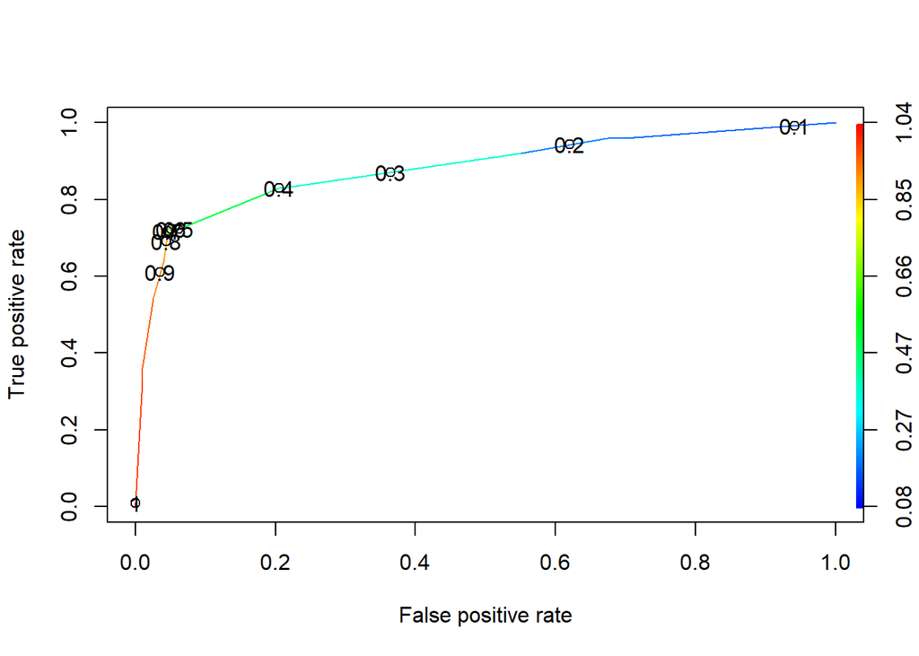

```r
ROCRPred <- prediction(predict(model.1.2, type='response'), training.cat$target)
ROCRPref <- performance(ROCRPred, 'tpr', 'fpr')
plot(ROCRPref, colorize=TRUE, print.cutoffs.at = seq(0.1, by=0.1))
```

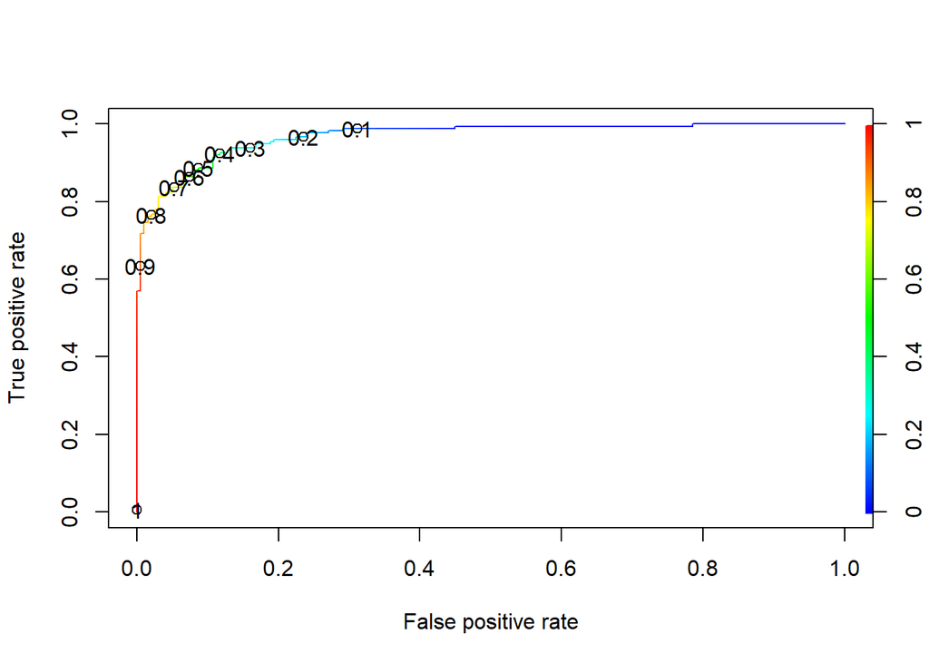

```r
ROCRPred <- prediction(predict(model.2, type='response'), training.log$target)
ROCRPref <- performance(ROCRPred, 'tpr', 'fpr')
plot(ROCRPref, colorize=TRUE, print.cutoffs.at = seq(0.1, by=0.1))
```

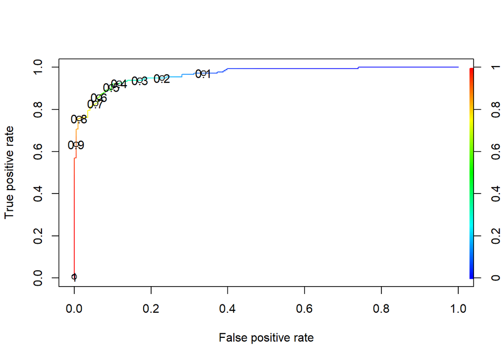

```r
ROCRPred <- prediction(predict(model.3, type='response'), training.cat$target)
ROCRPref <- performance(ROCRPred, 'tpr', 'fpr')
plot(ROCRPref, colorize=TRUE, print.cutoffs.at = seq(0.1, by=0.1))
```

I created confusion matrices on the previously set aside validation data set. While all three model perform well (79%, 83% and 87% respectively), it is the third model that performs the best on the validation data. This is despite the fact that it has a lower predictive value on the training data. This indicates to me that model 2 may suffer from some slight overfitting.

```r
predictions <- ifelse(predict(model.1.2, newdata=testing.cat, type='response') < 0.5, 0, 1)
caret::confusionMatrix(table(predicted=predictions, actual = testing.cat$target))
```

```
## Confusion Matrix and Statistics
##
##          actual
## predicted  0  1
##         0 38 16
##         1  3 36
##
##                Accuracy : 0.7957
##                  95% CI : (0.6995, 0.8723)
##     No Information Rate : 0.5591
##     P-Value [Acc > NIR] : 1.511e-06
##
##                   Kappa : 0.599
##  Mcnemar's Test P-Value : 0.005905
##
##             Sensitivity : 0.9268
##             Specificity : 0.6923
##          Pos Pred Value : 0.7037
##          Neg Pred Value : 0.9231
##              Prevalence : 0.4409
##          Detection Rate : 0.4086
##    Detection Prevalence : 0.5806
##       Balanced Accuracy : 0.8096
##
##        'Positive' Class : 0
##
```

```r
predictions <- ifelse(predict(model.2, newdata=testing.log, type='response') < 0.5, 0, 1)
caret::confusionMatrix(table(predicted=predictions, actual = testing.log$target))
```

```
## Confusion Matrix and Statistics
##
##          actual
## predicted  0  1
##         0 32  6
##         1  9 46
##
##                Accuracy : 0.8387
##                  95% CI : (0.748, 0.9068)
##     No Information Rate : 0.5591
##     P-Value [Acc > NIR] : 9.557e-09
##
##                   Kappa : 0.6703
##  Mcnemar's Test P-Value : 0.6056
##
##             Sensitivity : 0.7805
##             Specificity : 0.8846
##          Pos Pred Value : 0.8421
##          Neg Pred Value : 0.8364
##              Prevalence : 0.4409
##          Detection Rate : 0.3441
##    Detection Prevalence : 0.4086
##       Balanced Accuracy : 0.8326
##
##        'Positive' Class : 0
##
```

```r
predictions <- ifelse(predict(model.3, newdata=testing.log, type='response') < 0.5, 0, 1)
caret::confusionMatrix(table(predicted=predictions, actual = testing.log$target))
```

```
## Confusion Matrix and Statistics
##
##          actual
## predicted  0  1
##         0 34  5
##         1  7 47
##
##                Accuracy : 0.871
##                  95% CI : (0.7855, 0.9315)
##     No Information Rate : 0.5591
##     P-Value [Acc > NIR] : 9.719e-11
##
##                   Kappa : 0.7369
##  Mcnemar's Test P-Value : 0.7728
##
##             Sensitivity : 0.8293
##             Specificity : 0.9038
##          Pos Pred Value : 0.8718
##          Neg Pred Value : 0.8704
##              Prevalence : 0.4409
##          Detection Rate : 0.3656
##    Detection Prevalence : 0.4194
##       Balanced Accuracy : 0.8666
##
##        'Positive' Class : 0
##
```

I have decided to select model 3. Model 3 has demonstrated strong predictive ability on the validation set and has the added benefit of being less complex (featuring fewer predictors) than model 2. Below are the results on the evaluation data set.

```r
final.data <- read_csv('https://raw.githubusercontent.com/brian-cuny/621week3/master/crime-evaluation-data.csv') %>%
  mutate(chas.cat = factor(chas),
         zn.cat = factor(ifelse(zn == 0, 0, 1)),
         indus.cat = factor(ifelse(indus < 14, 0, 1)),
         rad.cat = factor(ifelse(rad <= 15, 0, 1)),
         tax.cat = factor(ifelse(tax <= 540, 0, 1)),
         black.cat = factor(ifelse(black <= 390, 0, 1))) %>%
  select(-chas, -zn, -indus, -rad, -tax, -black) %>%
  mutate(l.nox = log(nox),
         l.age = log(age),
         l.dis = log(dis),
         l.ptratio = log(ptratio))
to.output <- data_frame(prob = predict(model.3, newdata=final.data, type='response'),
                        class = ifelse(prob < 0.5, 0, 1)) %>%
              mutate(id = row_number()) %>%
              select(id, prob, class)
to.output
```

```
## # A tibble: 40 x 3
##       id    prob class
##    <int>   <dbl> <dbl>
##  1     1 0.251       0
##  2     2 0.926       1
##  3     3 0.944       1
##  4     4 0.777       1
##  5     5 0.0674      0
##  6     6 0.0289      0
##  7     7 0.142       0
##  8     8 0.0247      0
##  9     9 0.00686     0
## 10    10 0.00441     0
## # ... with 30 more rows
```

In conclusion, I have been able to make predictions on a variety of neighborhoods of a major city in order to determine whether the neighborhood is likely to be above the median crime rate or below the median crime rate. From the initial set of predictors, a subset was selected that demonstrated strong predictive ability. Testing the data on a withheld set produced 87% accuracy. It was this model that was used on the evaluation set. It is my hope that the model wil be able to produce similar results on the evaluation data.

## Appendix

I created a function to produce marginal model plots to determine whether each model is valid.

```r
Marginal.Model.Two <- function(p){
  yhat <- predict(model.2, type='response')
  p <- ggplot(training.log, aes_string(p, 'target')) +
    geom_point() +
    geom_smooth(method='loess', se=FALSE) +
    geom_smooth(aes(y=yhat), method='loess', se = FALSE, color='red', linetype='dotted')
  return(p)
}

Marginal.Model.Three <- function(p){
  yhat <- predict(model.3, type='response')
  p <- ggplot(training.log, aes_string(p, 'target')) +
    geom_point() +
    geom_smooth(method='loess', se=FALSE) +
    geom_smooth(aes(y=yhat), method='loess', se = FALSE, color='red', linetype='dotted')
  return(p)
}
```

### Model 1

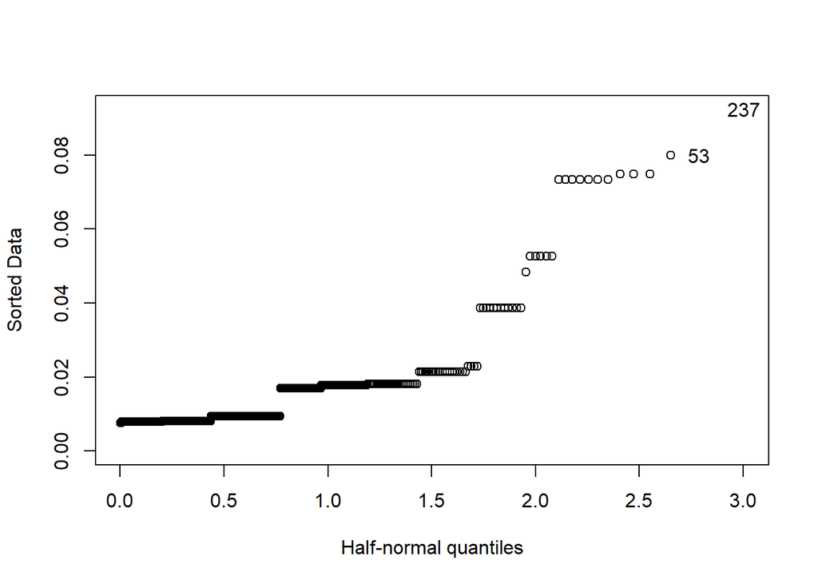

```r
faraway::halfnorm(hatvalues(model.1.2))
```

The halfnorm plot for model 1 appears to show a high leverage point in 237. As this is a single point across the entire model, and it does not appear to be too far off the quantile line, it is unlikely to be heavily skewing the model.

### Model 2

I must examine the non-categorical predictor variables’ marginal model plots.

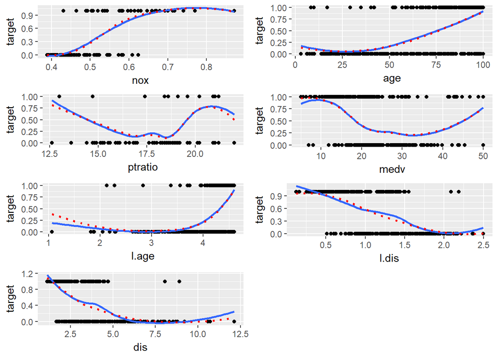

```r
require(gridExtra)
grid.arrange(Marginal.Model.Two('nox'), Marginal.Model.Two('age'), Marginal.Model.Two('ptratio'),
             Marginal.Model.Two('medv'), Marginal.Model.Two('l.age'), Marginal.Model.Two('l.dis'),
             Marginal.Model.Two('dis'), ncol=2)
```

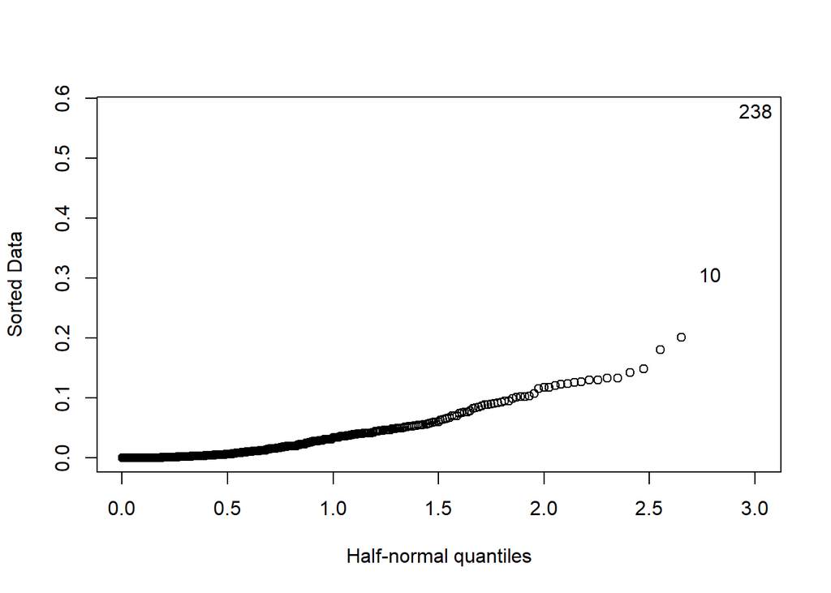

```r
faraway::halfnorm(hatvalues(model.2))
```

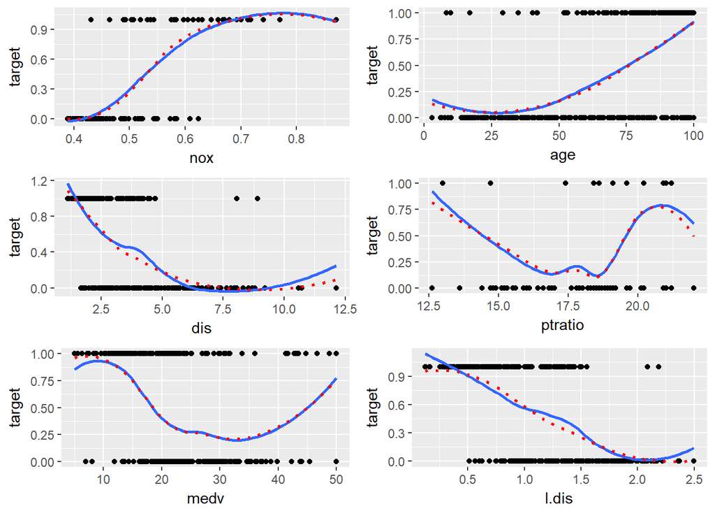

```r
require(gridExtra)
grid.arrange(Marginal.Model.Two('nox'), Marginal.Model.Two('age'), Marginal.Model.Two('dis'),
             Marginal.Model.Two('ptratio'), Marginal.Model.Two('medv'), Marginal.Model.Two('l.dis'), ncol=2)
```

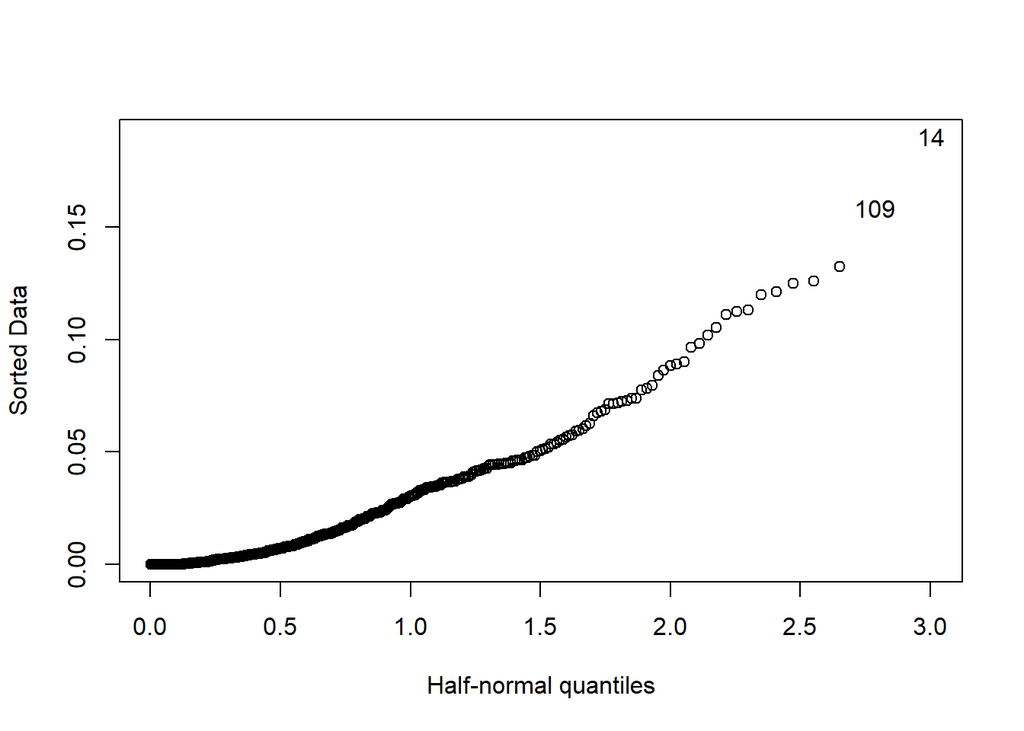

```r
faraway::halfnorm(hatvalues(model.3))
```